# tmplate

- **Name**: `Forking2`
- **Fully Qualified Name**: `org.openprovenance.templates.generic.Forking2`
- **IRI**: https://openprovenance.org/templates/org/openprovenance/templates/generic/Forking2
- **Purpose**: The template `Forking2` describes the transformation of an input resulting in two distinct outputs.
- **Context**: It is a general transformation applicable to many different contexts.
- **Design considerations**: Relations rigorously linking nodes using pre-defined triangles.
- **Automation**: ttfs/config-generic.json

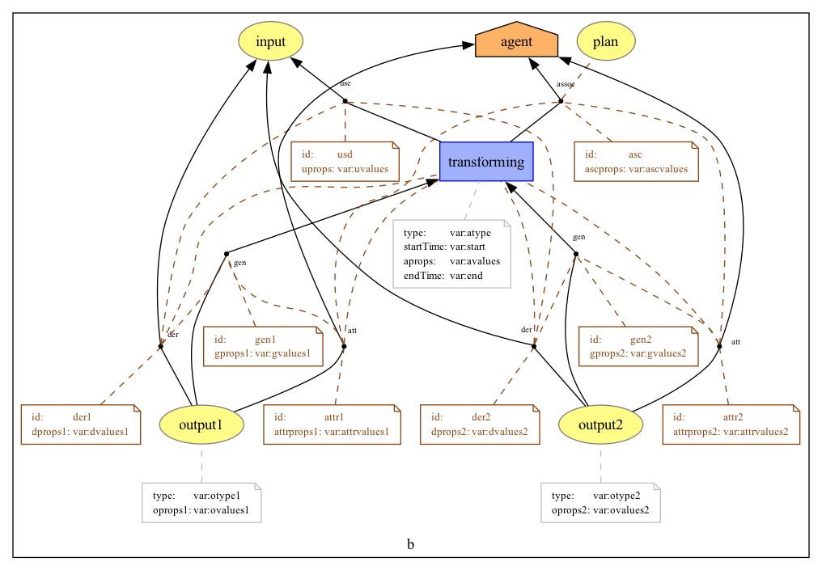

Figure 1: org.openprovenance.templates.generic.Forking2

- **Details**:

  There are three entities directly related to the transformation: `input`, `output1` and `output2`; an activity `transforming`; an agent `agent`; and an associated plan `plan`.

  The pattern has multiple applications, including creating two subprocesses, splitting a file, cutting a cake in two, or sharing the profits of a business operation.